[figure not shown]

Rear Wiring Harness LH

WIRING SYSTEM

71.Rear Wiring Harness LH

A: LOCATION

Connector Connecting to

No. Pole Color Area No. Description

AB17 15 Y B-1 Airbag CM

AB19 4 Y B-3 Side airbag module LH

AB21 2 B B-4 Pretensioner LH

AB23 4 Y B-4 Side airbag sensor LH

AB35 2 B C-2 F/B

R3 24 C-2 B99 Bulkhead wiring harness

R4 1 B B-3 Parking brake switch

R5 10 C-2 B92 Bulkhead wiring harness

R9 3 B-4 Front door switch LH

R10 8 B-4 D22 Rear door cord LH (without audio amplifier)

R18 12 B B-2 R21 Rear wiring harness LH

R41 4 B-3 Seat heater LH

R81 19 B B-2 R82 Rear wiring harness RH

R108 2 C-3 Seat belt switch LH

R110 2 B C-3 R205 Power seat LH

R123 2 C-2 AB62 Airbag wiring harness

R167 20 C-2 i102 Instrument panel wiring harness

R168 20 C-2 F/B

R339 20 C-2 i2 Instrument panel wiring harness

: White or natural color

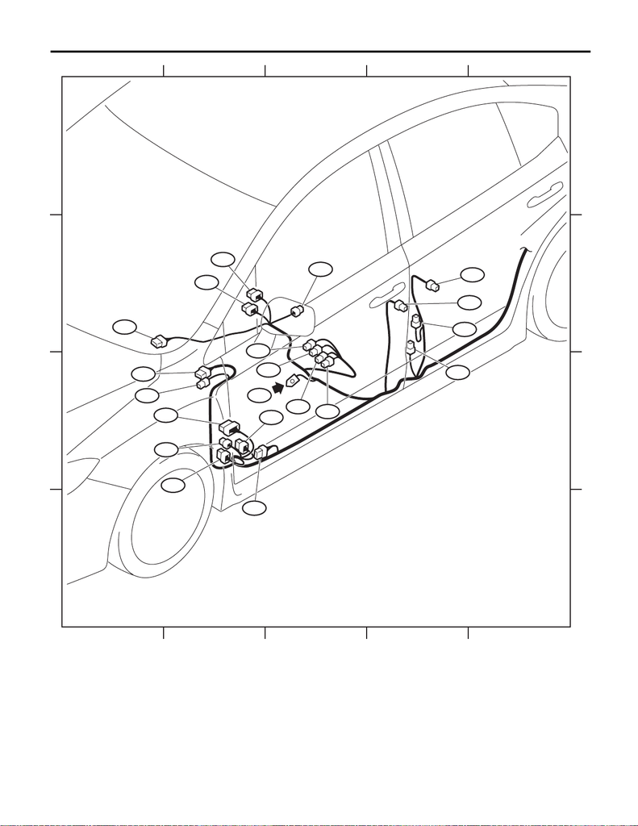

Rear Wiring Harness LH

WIRING SYSTEM

WI-44626

12345

12345

A

B

C

D

A

B

C

D

AB17

R81

R18

R4

R168

AB35

R3

R123

R339

R167

R5

AB21

AB23

R9

R10

R108

R110

R41

AB19

GB-9